# Analysis 1: UNC Salaries

Yuvraj Jain

February 09, 2023

# Instructions

**Overview:** For each question, show your R code that you used to answer each question in the provided chunks. When a written response is required, be sure to answer the entire question in complete sentences outside the code chunks. When figures are required, be sure to follow all requirements to receive full credit. Point values are assigned for every part of this analysis. **Do not work with other students on this assignment. You are to complete this assignment by yourself.**

**Helpful:** Make sure you knit the document as you go through the assignment. Check all your results in the created HTML file.

**Submission:** Submit via an electronic document on Canvas. Must be submitted as an HTML file generated in RStudio.

# Introduction

Universities are typically opaque, bureaucratic institutions. To be transparent to tax payers, many public schools, such as the University of North Carolina, openly report **[salary information](http://www.newsobserver.com/news/databases/public-salaries/)**. In this assignment, we will analyze this information from 2022 to answer pivotal questions that have endured over the course of time. The most recent salary data for UNC-Chapel Hill faculty and staff has already been downloaded in CSV format and titled *“Salary Data Export.csv”*.

To answer all the questions, you will need the R package `tidyverse` to make figures and utilize `dplyr` functions.

# Data Information

Make sure the CSV data file is contained in the folder of your RMarkdown file. First, we start by using the `read_csv` function from the `readr` package found within the tidyverse. The code below executes this process by creating a tibble in your R environment named “salary”.

```r
salary=read_csv("Salary Data Export.csv")
```

Now, we will explore the information that is contained in this dataset. The code below provides the names of the variables contained in the dataset.

```r
names(salary)
```

```
##  [1] "University" "Last_Name"  "First_Name" "INIT"       "Age"
##  [6] "Hire_Date"  "Category"   "Salary"     "Department" "Title"
```

Next, we will examine the type of data contains in these different variables.

```r
str(salary,give.attr=F)
```

```
## spc_tbl_ [13,001 × 10] (S3: spec_tbl_df/tbl_df/tbl/data.frame)
##  $ University: chr [1:13001] "UNC-CH" "UNC-CH" "UNC-CH" "UNC-CH" ...
##  $ Last_Name : chr [1:13001] "Jin" "Tien" "McManus" "Rizvi" ...
##  $ First_Name: chr [1:13001] "Guifeng" "Hsiao-Chuan" "James" "Imran" ...
##  $ INIT      : chr [1:13001] NA NA "M" NA ...
##  $ Age       : num [1:13001] 61 58 60 47 53 35 66 46 44 40 ...
##  $ Hire_Date : chr [1:13001] "1/27/1997" "11/1/2008" "1/13/2020" "7/1/2018" ...
##  $ Category  : chr [1:13001] "IT Database Professional, Database Administrator" "IT Database Professional, Data Administrator" "Research Professional, Mathematics / Computing / Statistics" "Assistant Professor" ...
##  $ Salary    : num [1:13001] 99998 99998 99988 99988 99975 ...
##  $ Department: chr [1:13001] "Carolina Population Center" "Carolina Population Center" "Renaissance Computing Inst" "Biomedical Engineering-UG" ...
##  $ Title     : chr [1:13001] "Applications Analyst" "Applications Analyst" "Research Scientist" "Assistant Professor" ...
```

You will notice that the variable “Hire_Date” is recorded as a character. The following code will first modify the original dataset to change this to a date variable with the format *mm/dd/yyyy*. Then, we will remove the hyphens to create a numeric variable as *yyyymmdd*. Finally, in the spirit of tidyverse, we will convert this data frame to a tibble.

```r
salary$Hire_Date=as.Date(salary$Hire_Date, format="%m/%d/%Y")
salary$Hire_Date=as.numeric(gsub("-","",salary$Hire_Date))
salary=as_tibble(salary)
```

Now, we will use `head()` to view of first five rows and the modifications made to the original data. The rest of the assignment will extend off this modified dataset named `salary` which by now should be in your global environment.

```r
head(salary,5)
```

```
## # A tibble: 5 × 10
##   University Last_Name First_…¹ INIT    Age Hire_…² Categ…³ Salary Depar…⁴ Title
##   <chr>      <chr>     <chr>    <chr> <dbl>   <dbl> <chr>    <dbl> <chr>   <chr>
## 1 UNC-CH     Jin       Guifeng  <NA>     61  2.00e7 IT Dat… 99998  Caroli… Appl…
## 2 UNC-CH     Tien      Hsiao-C… <NA>     58  2.01e7 IT Dat… 99998  Caroli… Appl…
## 3 UNC-CH     McManus   James    M        60  2.02e7 Resear… 99988  Renais… Rese…
## 4 UNC-CH     Rizvi     Imran    <NA>     47  2.02e7 Assist… 99988. Biomed… Assi…
## 5 UNC-CH     O'HARA    RICHARD  J        53  1.99e7 Resear… 99975  Caroli… Rese…
## # … with abbreviated variable names ¹First_Name, ²Hire_Date, ³Category,
## #   ⁴Department
```

# Assignment

## Part 1: Reducing the Data to a Smaller Set of Interest

### Q1 *(2 Points)*

Create a new dataset named `salary2` that only contains the following variables:

- “Last_Name”
- “First_Name”
- “Age”
- “Hire_Date”
- “Category”
- “Salary”
- “Department”
- “Title”

Then, use the `names()` function to display the variable names of `salary2`.

```r
salary2 = select(salary, c("Last_Name", "First_Name", "Age", "Hire_Date", "Category", "Salary", "Department", "Title"))
names(salary2)
```

```
## [1] "Last_Name"  "First_Name" "Age"        "Hire_Date"  "Category"
## [6] "Salary"     "Department" "Title"
```

### Q2 *(2 Points)*

Now, we modify `salary2`. Rename the variables “Last_Name”,“First_Name”, and “Hire_Date” to “Last”,“First”, and “Hire”, respectively. Do this for a new dataset called `salary3` and use `names()` to display the variable names of `salary3`.

```r
salary3 <- salary2 %>%
  rename(Last = Last_Name,
         First = First_Name,
         Hire = Hire_Date)
names(salary3)
```

```
## [1] "Last"       "First"      "Age"        "Hire"       "Category"
## [6] "Salary"     "Department" "Title"
```

### Q3 *(2 Points)*

Now, we modify `salary3`. Create a new variable called “HireYear” that only contains the first four digits of the variable “Hire_Date” in a new dataset named `salary4`. Use the function `str()` to ensure that your new variable “HireYear” reports the year of the date that the employee was hired. how

```r
salary4 <- salary3 %>%
  mutate(HireYear = Hire %/% 10000)
str(salary4)
```

```
## tibble [13,001 × 9] (S3: tbl_df/tbl/data.frame)
##  $ Last      : chr [1:13001] "Jin" "Tien" "McManus" "Rizvi" ...
##  $ First     : chr [1:13001] "Guifeng" "Hsiao-Chuan" "James" "Imran" ...
##  $ Age       : num [1:13001] 61 58 60 47 53 35 66 46 44 40 ...
##  $ Hire      : num [1:13001] 19970127 20081101 20200113 20180701 19931213 ...
##  $ Category  : chr [1:13001] "IT Database Professional, Database Administrator" "IT Database Professional, Data Administrator" "Research Professional, Mathematics / Computing / Statistics" "Assistant Professor" ...
##  $ Salary    : num [1:13001] 99998 99998 99988 99988 99975 ...
##  $ Department: chr [1:13001] "Carolina Population Center" "Carolina Population Center" "Renaissance Computing Inst" "Biomedical Engineering-UG" ...
##  $ Title     : chr [1:13001] "Applications Analyst" "Applications Analyst" "Research Scientist" "Assistant Professor" ...
##  $ HireYear  : num [1:13001] 1997 2008 2020 2018 1993 ...
```

### Q4 *(2 points)*

Now, we modify `salary4`. Create a new variable called “YrsEmployed” which reports the number of full years the employee has worked at UNC. Assume the current year is 2022 and assume that all employees are hired January 1. Create a new dataset named `salary5` and again use `str()` to display the variables in `salary5`.

```r
salary5 <- salary4 %>%
  mutate(YrsEmployed = 2022 - HireYear)
str(salary5)
```

```
## tibble [13,001 × 10] (S3: tbl_df/tbl/data.frame)
##  $ Last       : chr [1:13001] "Jin" "Tien" "McManus" "Rizvi" ...
##  $ First      : chr [1:13001] "Guifeng" "Hsiao-Chuan" "James" "Imran" ...
##  $ Age        : num [1:13001] 61 58 60 47 53 35 66 46 44 40 ...
##  $ Hire       : num [1:13001] 19970127 20081101 20200113 20180701 19931213 ...
##  $ Category   : chr [1:13001] "IT Database Professional, Database Administrator" "IT Database Professional, Data Administrator" "Research Professional, Mathematics / Computing / Statistics" "Assistant Professor" ...
##  $ Salary     : num [1:13001] 99998 99998 99988 99988 99975 ...
##  $ Department : chr [1:13001] "Carolina Population Center" "Carolina Population Center" "Renaissance Computing Inst" "Biomedical Engineering-UG" ...
##  $ Title      : chr [1:13001] "Applications Analyst" "Applications Analyst" "Research Scientist" "Assistant Professor" ...
##  $ HireYear   : num [1:13001] 1997 2008 2020 2018 1993 ...
##  $ YrsEmployed: num [1:13001] 25 14 2 4 29 1 23 2 11 8 ...
```

### Q5 *(4 points)*

Now, we modify `salary5` to create our final dataset named `salary.final`. Use the pipe `%>%` to make the following changes:

- Drop the variables “Hire”, “HireYear”, and “First”.
- Sort the observations first by “YrsEmployed” and then by “Salary”, both in descending order from largest to smallest.
- Rearrange the variables so that “YrsEmployed” and “Salary” are the first two variables in the dataset, in that order, without removing any of the other variables.

After you have used the `%>%` to make these changes, use the function `head()` to display the first 12 rows of `salary.final`.

```r
salary.final <- salary5 %>%
  select(-c(Hire, HireYear, First)) %>%
  arrange(desc(YrsEmployed), desc(salary))

head(salary.final, 12)
```

```
## # A tibble: 12 × 7
##    Last          Age Category                       Salary Depar…¹ Title YrsEm…²
##    <chr>       <dbl> <chr>                           <dbl> <chr>   <chr>   <dbl>
##  1 SPENCER        88 Professor                      4.45e4 Psychi… Clin…      59
##  2 SEARING        80 Professor                      1.52e5 Politi… Dist…      55
##  3 PIZER          80 Professor                      1.78e5 Comput… Dist…      55
##  4 Koch           80 Professor                      1.66e5 Biosta… Prof…      55
##  5 ROSEFIELDE     79 Professor                      1.12e5 Econom… Prof…      52
##  6 Oehler         77 Professor                      1.13e5 Music   Prof…      51
##  7 ARENDSHORST    77 Professor                      1.80e5 Cell B… Prof…      51
##  8 Pendergraph    68 Administrative Assistant       5.03e4 SA Uni… Busi…      50
##  9 JONES          69 Student Affairs / Student Ser… 7.90e4 School… Dire…      50
## 10 FOWLER         82 Professor                      2   e4 OBGYN-… Clin…      49
## 11 WHITE          85 Professor                      1.38e5 ASOD O… Prof…      48
## 12 STRAUSS        74 Assoc/Asst Provost             3.01e5 OEVCP … Vice…      48
## # … with abbreviated variable names ¹Department, ²YrsEmployed
```

## Part 2: Answering Questions Based on All Data

In these questions,find the answer using code, and then answer the question using complete sentences below the code.

### Q6 *(2 Points)*

What is the average salary of employees in my department (Statistics and Operations Research)?

Code *(1 Point)*:

```r
avg_salary <- salary.final %>%
  group_by(Department) %>%
  summarize(mean = mean(Salary)) %>%
  filter(Department == "Statistics and Operations Res")
avg_salary
```

```
## # A tibble: 1 × 2
##   Department                       mean
##   <chr>                           <dbl>
## 1 Statistics and Operations Res 125739.
```

Answer *(1 Point)*: The average salary of employees working in the Statistics and Operations Research Department is $125,739.4

### Q7 *(4 Points)*

How many employees have worked in History between 0 and 5 years (inclusive)?

Code *(2 Points)*:

```r
history <- salary.final %>%
  filter(YrsEmployed <= 5, Department == "History")
history
```

```
## # A tibble: 5 × 7
##   Last            Age Category                      Salary Depar…¹ Title YrsEm…²
##   <chr>         <dbl> <chr>                          <dbl> <chr>   <chr>   <dbl>
## 1 Anderson         61 Administrative / Office / Cl… 4.84e4 History Admi…       5
## 2 Gellman          46 Associate Professor           9.24e4 History Asso…       4
## 3 Silva Campo      37 Assistant Professor           7.6 e4 History Assi…       3
## 4 Moses            55 Professor                     1.60e5 History Dist…       2
## 5 Louie-Meadors    27 Student Services Coordinator  4.73e4 History Stud…       0
## # … with abbreviated variable names ¹Department, ²YrsEmployed
```

Answer *(2 Points)*: There are 5 employees who have worked in the History Department between 0 and 5 years. (inclusive)

### Q8 *(4 Points)*

What is the difference between the average age of employees in the History department who are professors, associate professors, or assistant professors and the average age of employees in my department who are professors, associate professors, or assistant professors?

Code *(2 Points)*:

```r
average_age_stor <- salary.final %>%
  filter(Department == "Statistics and Operations Res") %>%
  filter(Category %in% c("Professor", "Associate Professor", "Assistant Professor")) %>%
  summarize(mean(Age))

average_age_hist <- salary.final %>%
  filter(Department == "History") %>%
  filter(Category %in% c("Professor", "Associate Professor", "Assistant Professor")) %>%
  summarize(mean(Age))

average_age_hist - average_age_stor
```

```
##   mean(Age)
## 1  8.704878
```

Answer *(2 Points)*: The average age of professors, associate professor, or assistant professors in the History department is about 8.7 years older than those in the STOR department. Note that I have assumed that we are looking for professors, associate professors, or assistant professors in the Category column and not the Title column. In my analysis, even distinguished professors are considered professors, which made sense to include in the type of analysis I was trying to do here.

## Part 3: Answering Questions Based on Summarized Data

### Q9 *(4 Points)*

Based off the data in `salary.final`, create a grouped summary based off combinations of “Department” and “Title”. Call the new tibble `dept_title_summary`. Your summarized tibble, `dept_title_summary`, should report all of the following statistics with corresponding variable names in the following order.

- “n” = number of employees for each combination
- “salary” = average salary for each combination
- “age” = average age for each combination
- “corr” = correlation between the salary and age for each combination

In the process, make sure you use `ungroup()` with the pipe `%>%` to release the grouping so future work is no longer group specific. Also, the `cor()` can be used to calculate the correlation between two variables.

Following the creation of `dept_title_summary`, prove that your code worked by using `head()` to view the first 12 rows.

```r
dept_title_summary = salary.final %>%
  group_by(Department, Title) %>%
  summarize(n = n(),
            salary = mean(Salary),
            age = mean(Age),
            corr = cor(x = Salary, y = Age)) %>%
  ungroup()
head(dept_title_summary, 12)
```

```
## # A tibble: 12 × 6
##    Department                     Title                   n salary   age    corr
##    <chr>                          <chr>               <int>  <dbl> <dbl>   <dbl>
##  1 Acad Sup Prog Student-Athletes Academic Advisor        1 4.97e4  35   NA
##  2 Acad Sup Prog Student-Athletes Academic Counselor      6 5.17e4  41.2  0.353
##  3 Acad Sup Prog Student-Athletes Assistant Director      3 5.68e4  36.3 -0.935
##  4 Acad Sup Prog Student-Athletes Associate Director      3 8.37e4  43.3  0.379
##  5 Acad Sup Prog Student-Athletes Director                1 1.41e5  52   NA
##  6 Academic Advising              Academic Advisor       13 5.05e4  40.5  0.212
##  7 Academic Advising              Academic Coordinat…     1 5.23e4  33   NA
##  8 Academic Advising              Admin Support Spec…     5 4.46e4  54.8  0.437
##  9 Academic Advising              Assistant Dean          6 7.52e4  53.3 -0.0131
## 10 Academic Advising              Associate Dean          1 1.32e5  37   NA
## 11 Academic Advising              Associate Director      1 6.50e4  37   NA
## 12 Academic Advising              Business Services …     1 4.84e4  29   NA
```

### Q10 *(4 Points)*

Using the summarized data in `dept_title_summary`, use the `dplyr` functions to identify the 5 departments that award the highest average salary for assistant professors. **Only consider departments that have at least 3 assistant professors in their department.** The output should only show the names of the 5 departments along with the corresponding average salary.

Code:

```r
high_avg_salary <- dept_title_summary %>%
  filter(n >= 3, Title == "Assistant Professor") %>%
  group_by(Department) %>%
  arrange(desc(salary)) %>%
  select(Department, salary)

head(high_avg_salary, 5)
```

```
## # A tibble: 5 × 2
## # Groups:   Department [5]
##   Department                      salary
##   <chr>                            <dbl>
## 1 Radiation Oncology-Chapel Hill 293083.
## 2 Medicine - Cardiology          268750
## 3 Kenan-Flagler Bus Sch          215296.
## 4 Medicine-Oncology              207833.
## 5 Medicine-Hematology            206791.
```

### Q11 *(4 points)*

Create a scatter plot using `geom_point()` along with fitted lines using `geom_smooth` with the argument `method="lm"` showing the linear relationship between average salary and the average age. Put the average age on the x-axis of your plot. **For this plot, use the summarized data in `dept_title_summary` and exclude the combinations of Department and Title where there are less than 5 employees.**

Following the plot, please explain what this plot suggests about the relationship between the average salary and the average age. Make reference to the figure and use descriptive adjectives (i.e. “strong”, “weak”, etc.) and terms (i.e. “positive”, “negative”, etc.) that are appropriate for discussing linear relationships.

Code and Figure *(2 Points)*:

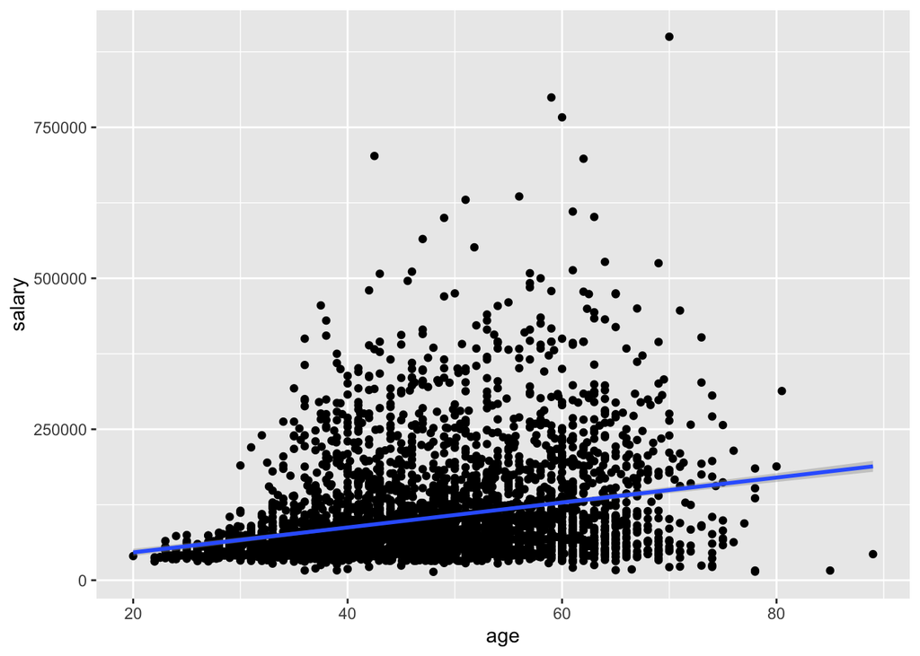

```r
ggplot(data = dept_title_summary, mapping = aes(x = age, y = salary)) +
  geom_point() +
  geom_smooth(method = "lm")
```

Answer *(2 Points)*: From the above graph, we can see a positive relationship between age and salary. We can see that older people have a higher salary and with increase in age, salary also increases, as suggested by the blue line which has a positive slope. Most of the data is under the salary of $250k but we can also see a few outliers who have a really high salary compared to the rest of the demographic. It would be interesting, in my opinion, to see what the slope would look like if we were to remove the outliers, i.e, how much are the outliers swaying the line towards a positive slope, if at all?